# Taylor Okonek

she/her

Email [Github](https://github.com/taylorokonek) [Google Scholar](https://scholar.google.com/citations?user=SO9X2IwAAAAJ&hl=en&authuser=1)

External Affiliate of the [Center for Studies in Demography and Ecology](https://csde.washington.edu/).

External Member of the [Minnesota Population Center](https://pop.umn.edu/).

Download my CV [here](https://drive.google.com/file/d/1Iqolo6czuWVmEeR0nrQROWoBMdOHFsjv/view?usp=sharing).

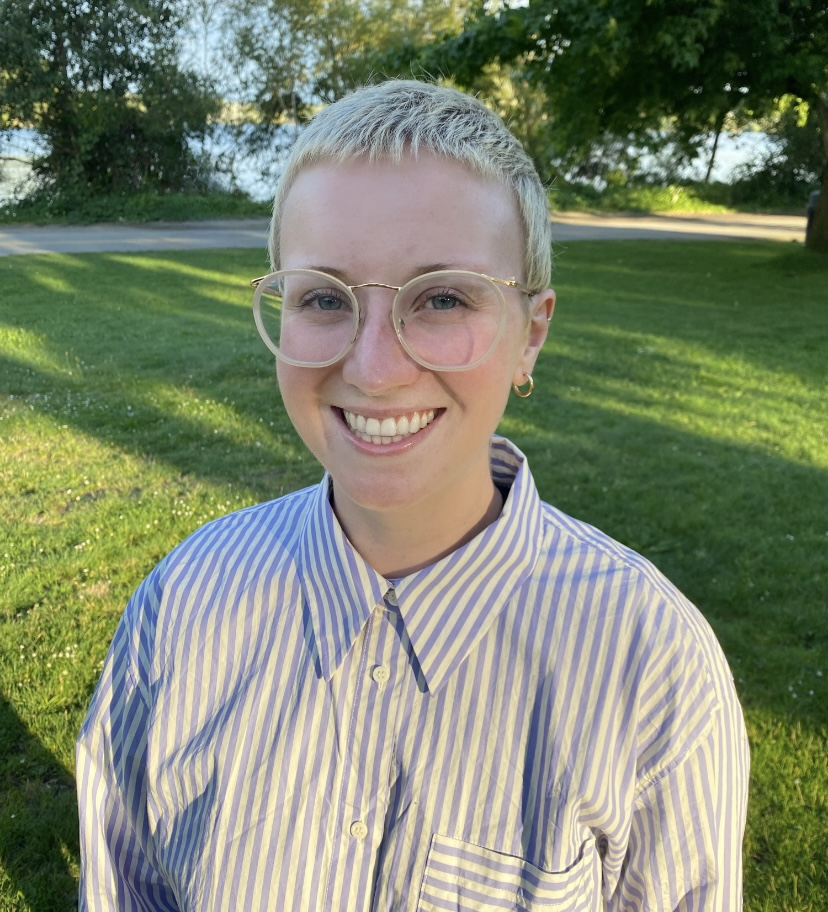

### About Me

Welcome to my personal website! I’m an Assistant Professor of Statistics in the [Department of Mathematics, Statistics, and Computer Science](https://www.macalester.edu/mscs/) at [Macalester College](https://www.macalester.edu/). I completed my Ph.D. in Biostatistics in 2023 at the [University of Washington](http://www.biostat.washington.edu/), advised by [Jon Wakefield](http://faculty.washington.edu/jonno/). My research interests include small area estimation, demography, survival analysis, and statistical methods for use in official statistics and complex survey data settings. I am particularly interested in applications related to demography and thinking about creative ways to improve the computational efficiency of statistical methods, and much of my work is thusly focused. My current research extends existing methods for estimating mortality across time from complex survey data using continuous, parametric survival models.

During my Ph.D., I worked as a research assistant under the supervision of my dissertation advisor. Our work focused on spatio-temporal methods for under-5 mortality estimation and HIV prevalence estimation, primarily in sub-Saharan Africa. We have previously developed methodology for benchmarking subnational estimates to national level estimates in a computationally efficient, Bayesian framework. This work is particularly important in the realm of official statistics, where a certain level of agreement between national level estimates and subnational estimates is often required.

I completed my B.A. in Mathematics and Religion (separate degrees, there is no degree in both Math and Religion that I’m aware of), with a concentration in Statistics at St. Olaf College in Northfield, MN. I grew up on Madeline Island, WI, and in St. Paul, MN, and in my spare time I enjoy reading, cooking, video games, hiking, and hanging out with my three cats (Alice, Ellie, and Norra).